# Multinomial Regression

```r
library(stargazer)
library(nnet)
library(caret)
```

```r
df <- read.csv("~/Documents/GitHub/CSS206/ReplicationData/cleaned.csv")

dim(df)
```

```
[1] 7850  123
```

```r
#originial data frame has 7850 obs X 123 variables

str(df)
```

```
'data.frame':   7850 obs. of  123 variables:
 $ codpanelista2     : int  3 3 3 3 5 5 5 5 8 10 ...
 $ wave              : int  9 10 11 12 9 10 11 12 9 9 ...
 $ sex               : int  2 2 2 2 1 1 1 1 2 2 ...
 $ age               : int  33 34 35 36 27 28 29 30 35 26 ...
 $ education         : int  3 3 3 3 8 8 8 8 8 10 ...
 $ femindexa         : int  3 2 4 3 1 2 2 2 4 3 ...
 $ femindexb         : int  6 5 3 5 2 6 6 5 4 4 ...
 $ femindexc         : int  2 3 4 3 2 2 1 5 4 3 ...
 $ femindexd         : int  4 2 4 3 2 2 2 2 4 4 ...
 $ femindexe         : int  3 3 4 4 2 2 2 3 4 4 ...
 $ femindexf         : int  7 7 2 5 5 5 5 6 4 4 ...
 $ femindexg         : int  6 6 4 5 5 5 5 5 5 5 ...
 $ femindexh         : int  3 3 4 4 3 4 3 3 4 4 ...
 $ femindexi         : int  2 1 4 4 2 1 2 3 4 5 ...
```

[output cut: 86 more lines]

Variables of interest :

- Dependent variable - voteintentionspain (categorical - order doesn’t matter)
  - 1 PSOE
  - 2- PP
  - 3- Podemos
  - 4 - Ciduadanos
  - 7- ERC (Catalonia)
  - 23 - Vox
- Independent variables
  - education - as.factor(edu3) - this variable represents 1 “Lower secondary”, 2 “Upper secondary”, 3 “Tertiary”
  - income - dhincome_all - Normalized income (range 0–1)
  - female - (0,1)
  - nativism (percent)
  - msexism (percent)
  - femdemonstrate (1- YES 2- No)
- Why we chose these variables?
  - nativism- because anti-immigrant rhetoric is used in political campaigns to varying degrees across political spectrum
  - do people who protest vote for feminist parties? - feminist protest
  - msexism - are people who are more sexist, voting for parties with these beliefs

```r
#CLEAN the data

#POLITICAL PARTIES OF INTEREST

# Step 1: Define the parties we want to look at
keep_codes <- c(1, 2, 3, 4, 7, 23)

# Step 2: Filter the DataFrame
df_clean <- df[df$voteintentionspain %in% keep_codes, ]


#IND VARS OF INTEREST

# Step 1: Select only the relevant columns
df_clean <- df_clean[, c(
  "voteintentionspain",   # Dependent variable (now a factor with 6 categories)
  "edu3",                # For education
  "dhincome_all",         # Income
  "female",               # 0 = male, 1 = female
  "nativism",             # Percent
  "msexism",              # Percent
  "femdemonstrate"        # 1 = Yes, 2 = No
)]

# Recode: 2 (No) becomes 0
df_clean$femdemonstrate[df_clean$femdemonstrate == 2] <- 0

table(df_clean$voteintentionspain)
```

```
   1    2    3    4    7   23
1230  590  901  966  236  299
```

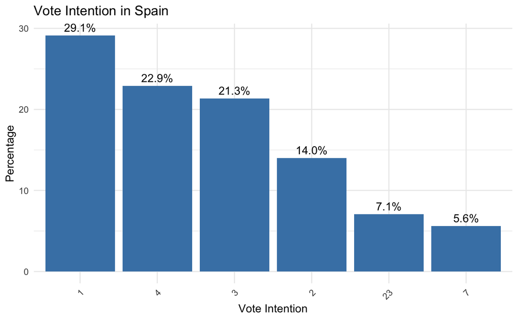

```r
library(ggplot2)
library(dplyr)

# Create a proportion table as a data frame
df_clean %>%
  count(voteintentionspain) %>%
  mutate(percentage = n / sum(n) * 100) %>%
  ggplot(aes(x = reorder(voteintentionspain, -percentage), y = percentage)) +
  geom_bar(stat = "identity", fill = "steelblue") +
  geom_text(aes(label = sprintf("%.1f%%", percentage)), vjust = -0.5) +
  labs(title = "Vote Intention in Spain",
       x = "Vote Intention",
       y = "Percentage") +
  theme_minimal() +
  theme(axis.text.x = element_text(angle = 45, hjust = 1))
```

```r
#Removing NA's
str(df_clean)
```

```
'data.frame':   4222 obs. of  7 variables:
 $ voteintentionspain: int  4 4 23 23 7 4 1 3 1 4 ...
 $ edu3              : int  1 1 1 1 3 3 3 3 1 1 ...
 $ dhincome_all      : num  0.182 0.182 0.273 0.182 0.545 ...
 $ female            : int  1 1 1 1 0 1 1 0 0 1 ...
 $ nativism          : num  0.65 0.45 0.65 0.75 0.35 ...
 $ msexism           : num  0.241 0.204 0.556 0.389 0.204 ...
 $ femdemonstrate    : num  NA 1 0 0 0 NA 0 NA NA NA ...
```

```r
df_clean <- df_clean[!is.na(df_clean$femdemonstrate) & !is.na(df_clean$dhincome_all), ]

col_missing_values <- sapply(df_clean, function(x) sum(is.na(x)))

# Print the number of missing values for each column
print(col_missing_values)
```

```
voteintentionspain               edu3       dhincome_all             female           nativism            msexism     femdemonstrate
                 0                  0                  0                  0                  0                  0                  0
```

```r
#3034 observations after NA's removed

write.csv(df_clean, "df_clean.csv", row.names = FALSE)
```

#Model 1